#Including required packages

```r
getwd()
```

```
## [1] "/home/yashk/Documents/DBMS-Workspace/Practicum1"
```

```r
# 1. Library (must be installed prior to loading
library(RMySQL)     ### MySQL
library(tidyr)      ### tidyr Seperating rows for handling multivalued attributes
library(sqldf)      ### SQLdf for using SQL commands on dataframes
options(sqldf.driver = "SQLite")
library(dplyr)      ### dplyr for splitting dataframes
```

#Reading CSV file

```r
#2. CSV File Name:
#setwd("Documents/DBMS-Workspace/Practicum1")
file_csv <- 'BirdStrikesData.csv'

df1 <- read.csv(file_csv)
df2 <- separate_rows(df1, Conditions..Precipitation)
```

#Setting up the database connection

```r
# 4. Settings
db_user <- 'root'
db_password <- 'Password@123'
db_name <- 'practicum1'

# Local: localhost
db_host <- 'localhost'
db_port <- 3306 # always this port unless you change it during installation

# 4. Connect to DB
mydb <-  dbConnect(MySQL(), user = db_user, password = db_password,
                dbname = db_name, host = db_host, port = db_port)

#To send Local Variables we write the below statement
dbSendQuery(mydb, "SET GLOBAL local_infile = true;")
```

```
## <MySQLResult:12,0,0>
```

```r
#dbListTables(mydb)
```

#Defining Schema of the database #Dropping Tables

```r
query<- ("DROP TABLE IF EXISTS practicum1.`bird_strike_incident`;");
dbSendQuery(mydb, query);
```

```
## <MySQLResult:12,0,1>
```

```r
query<- ("DROP TABLE IF EXISTS practicum1.`airport`;");
dbSendQuery(mydb, query);
```

```
## <MySQLResult:1751607660,0,2>
```

```r
query<- ("DROP TABLE IF EXISTS practicum1.`precipitation`;");
dbSendQuery(mydb, query);
```

```
## <MySQLResult:12,0,3>
```

```r
query<- ("DROP TABLE IF EXISTS practicum1.`precipitation_type`;");
dbSendQuery(mydb, query);
```

```
## <MySQLResult:1415536430,0,4>
```

```r
query<- ("DROP TABLE IF EXISTS practicum1.`wildlife`;");
dbSendQuery(mydb, query);
```

```
## <MySQLResult:774744832,0,5>
```

```r
query<- ("DROP TABLE IF EXISTS practicum1.`airline_aircrafts`;");
dbSendQuery(mydb, query);
```

```
## <MySQLResult:12,0,6>
```

```r
query<-("DROP TABLE IF EXISTS practicum1.`airline_operator`;");
dbSendQuery(mydb, query);
```

```
## <MySQLResult:741973680,0,7>
```

```r
query<-("DROP TABLE IF EXISTS practicum1.`aircraft`;");
dbSendQuery(mydb, query);
```

```
## <MySQLResult:12,0,8>
```

```r
dbListTables(mydb);
```

```
## character(0)
```

#Table Defination aircraft

```r
query<-("
  CREATE TABLE IF NOT EXISTS practicum1.`aircraft` (
  `AircraftTypeID` INT NOT NULL AUTO_INCREMENT,
  `Type` VARCHAR(45) DEFAULT ' ',
  `Make_Model` VARCHAR(45) DEFAULT ' ',
  `IsAircraftLarge` TINYINT DEFAULT 0,
  CONSTRAINT unique_constraint UNIQUE(Type,Make_Model,IsAircraftLarge),
  PRIMARY KEY (`AircraftTypeID`));
");

dbSendQuery(mydb, query);
```

```
## <MySQLResult:0,0,10>
```

#Table Defination airline_operator

```r
query<-("
  CREATE TABLE IF NOT EXISTS practicum1.`airline_operator` (
  `AirlineOperatorId` INT NOT NULL AUTO_INCREMENT,
  `AirlineOperator` VARCHAR(45) DEFAULT ' ' NULL UNIQUE,
  PRIMARY KEY (`AirlineOperatorId`));");

dbSendQuery(mydb, query);
```

```
## <MySQLResult:855148664,0,11>
```

#Table Defination airline_aircrafts

```r
query <- ("
  CREATE TABLE IF NOT EXISTS practicum1.`airline_aircrafts` (
  `PlaneID` INT NOT NULL AUTO_INCREMENT,
  `AircraftTypeID` INT NULL,
  `AirlineOperatorID` INT NULL,
  `NumberOfEngines` INT  DEFAULT 0 NULL,
  CONSTRAINT unique_constraint UNIQUE (AircraftTypeID,AirlineOperatorID,NumberOfEngines),
  PRIMARY KEY (`PlaneID`),
  FOREIGN KEY (`AircraftTypeID`) REFERENCES practicum1.`aircraft` (`AircraftTypeID`),
  FOREIGN KEY (`AirlineOperatorID`) REFERENCES practicum1.`airline_operator` (`AirlineOperatorId`));

  ");


dbSendQuery(mydb, query)
```

```
## <MySQLResult:796672736,0,12>
```

#Table Defination wildlife

```r
query <- ("
  CREATE TABLE IF NOT EXISTS practicum1.`wildlife` (
  `WildlifeID` INT NOT NULL AUTO_INCREMENT,
  `Species` VARCHAR(45) DEFAULT ' ' NULL,
  `Size` ENUM('Small', 'Medium', 'Large') DEFAULT 'Small' NULL,
  CONSTRAINT unique_constraint UNIQUE (Species, Size),
  PRIMARY KEY (`WildlifeID`));");

dbSendQuery(mydb, query)
```

```
## <MySQLResult:855208064,0,13>
```

#Table Defination precipitation_type

```r
query <- ("
  CREATE TABLE IF NOT EXISTS practicum1.`precipitation_type` (
  `PrecipitationID` INT NOT NULL AUTO_INCREMENT,
  `Precipitation_Type` VARCHAR(45) DEFAULT ' ' NULL UNIQUE,
  PRIMARY KEY (`PrecipitationID`));");

dbSendQuery(mydb, query)
```

```
## <MySQLResult:855516888,0,14>
```

#Table Defination precipitation

```r
query <- ("
  CREATE TABLE IF NOT EXISTS practicum1.`precipitation` (
  `RecordID` INT NOT NULL,
  `PrecipitationID` INT NOT NULL,
  PRIMARY KEY (`RecordID`, `PrecipitationID`),
  FOREIGN KEY (`PrecipitationID`) REFERENCES practicum1.`precipitation_type` (`PrecipitationID`));");

dbSendQuery(mydb, query)
```

```
## <MySQLResult:746324512,0,15>
```

#Table Defination airport

```r
query <- ("
  CREATE TABLE IF NOT EXISTS practicum1.`airport` (
  `AirportID` INT NOT NULL AUTO_INCREMENT,
  `Name` VARCHAR(45) DEFAULT ' ' NULL,
  `State` VARCHAR(45) DEFAULT ' ' NULL,
  CONSTRAINT unique_constraint UNIQUE (Name,State),
  PRIMARY KEY (`AirportID`));");

dbSendQuery(mydb, query)
```

```
## <MySQLResult:773707296,0,16>
```

#Table Defination bird_strike_incident

```r
query <- ('CREATE TABLE IF NOT EXISTS practicum1.`bird_strike_incident` (
  `RecordID` INT NOT NULL AUTO_INCREMENT,
  `FlightDate` DATETIME NULL,
  `WildLife_NumberOfStruck` VARCHAR(80) NULL,
  `WildLife_NumberOfStruckActual` INT NULL,
  `Effect_ImpactToFlight` VARCHAR(80) NULL,
  `Altitude_Bin` VARCHAR(10) NULL,
  `EffectIndicatedDamage` VARCHAR(20) NULL,
  `PhaseOfFlight` ENUM("Approach", "Climb", "Descent", "Landing Roll", "Take-off run", "Taxi") NULL,
  `WildLifeRemainsCollected` VARCHAR(50) NULL,
  `WildLifeRemainsSent` VARCHAR(50) NULL,
  `Remarks` LONGTEXT NULL,
  `PilotWarned` VARCHAR(50) NULL,
  `Cost_Total` INT NULL,
  `FeetAboveGround` INT NULL,
  `PeopleInjured` INT NULL,
  `ConditionsSky` VARCHAR(50) NULL,
  `PlaneID` INT NULL,
  `WildlifeID` INT NULL,
  `AirportID` INT NULL,
  PRIMARY KEY (`RecordID`),
  FOREIGN KEY (`PlaneID`) REFERENCES practicum1.`airline_aircrafts` (`PlaneID`),
  FOREIGN KEY (`WildlifeID`) REFERENCES practicum1.`wildlife` (`WildlifeID`),
  FOREIGN KEY (`AirportID`) REFERENCES practicum1.`airport` (`AirportID`));');

dbSendQuery(mydb, query);
```

```
## <MySQLResult:855521624,0,17>
```

#Loading data into aircraft table

```r
aircraft <- sqldf('SELECT DISTINCT "Aircraft..Make.Model" AS Make_Model, "Aircraft..Type" AS Type, "Is.Aircraft.Large." AS IsAircraftLarge  FROM df1')
aircraft[aircraft$IsAircraftLarge == "Yes",]$IsAircraftLarge <- 1
aircraft[aircraft$IsAircraftLarge == "No",]$IsAircraftLarge <- 0
#aircraft
#aircraft$AircraftTypeID<- 1:354
aircraft$IsAircraftLarge<- as.integer(aircraft$IsAircraftLarge)
dbWriteTable(mydb, name = "aircraft", value= aircraft, append = TRUE,row.names=FALSE, overwrite = FALSE)
```

```
## [1] TRUE
```

#Loading into airpline_operator table

```r
airline_operator <- sqldf('SELECT DISTINCT "Aircraft..Airline.Operator" AS AirlineOperator FROM df1')
#airline_operator
#airline_operator$AirlineOperatorID <- 1:293
dbWriteTable(mydb, name = "airline_operator", value= airline_operator, append = TRUE,row.names=FALSE)
```

```
## [1] TRUE
```

#Loading into airline_aircrafts table

```r
aircraft <- dbGetQuery(mydb, "SELECT * FROM `aircraft`;")

airline_operator <- dbGetQuery(mydb, "SELECT * FROM `airline_operator`;")

airline_aircrafts <- sqldf("SELECT DISTINCT aircraft.AircraftTypeID, airline_operator.airlineOperatorID, df1.`Aircraft..Number.of.engines.` AS `NumberOfEngines`
                           FROM aircraft INNER JOIN airline_operator INNER JOIN df1
                           WHERE aircraft.`Make_Model` = df1.`Aircraft..Make.Model` AND
                           airline_operator.AirlineOperator = df1.`Aircraft..Airline.Operator`;")

dbWriteTable(mydb, name = "airline_aircrafts", value= airline_aircrafts, append = TRUE,row.names=FALSE, overwrite = FALSE)
```

```
## [1] TRUE
```

#Loading into wildlife table

```r
wildlife <- sqldf('SELECT DISTINCT "Wildlife..Species" AS Species, "Wildlife..Size" AS Size
                  FROM df1')
#If dbWriteTable
#wildlife$WildlifeID <- 1:395
#wildlife
dbWriteTable(mydb, name = "wildlife", value= wildlife, append = TRUE,row.names=FALSE)
```

```
## [1] TRUE
```

#Loading into airport table

```r
airport <- sqldf('SELECT DISTINCT "Airport..Name" AS NAME, "Origin.State" AS State FROM df1')
#airport
#airport$AirportID<- 1:1141
dbWriteTable(mydb, name = "airport", value= airport, append = TRUE,row.names=FALSE)
```

```
## [1] TRUE
```

#Loading data into precipitation_type table

```r
precipitation_type <- sqldf('SELECT DISTINCT "Conditions..Precipitation" AS Precipitation_Type
                            FROM df1
                            WHERE Precipitation_Type NOT LIKE "%,%"')
#precipitation_type
dbWriteTable(mydb, name = "precipitation_type", value= precipitation_type, append = TRUE,row.names=FALSE)
```

```
## [1] TRUE
```

#Loading data into precipitation

```r
precipitation_type <- dbGetQuery(mydb, "SELECT * FROM `precipitation_type`;")

precipitation <- sqldf("SELECT df2.`Record.ID` AS RecordID, PrecipitationID
                       FROM df2 INNER JOIN precipitation_type
                       ON df2.'Conditions..Precipitation'= precipitation_type.Precipitation_Type;")
dbWriteTable(mydb, name = "precipitation", value= precipitation, append = TRUE,row.names=FALSE)
```

```
## [1] TRUE
```

#Loading data into bird_strike_incident table

```r
cname <- c("Record.ID", "FlightDate", "Wildlife..Number.struck", "Wildlife..Number.Struck.Actual", "Effect..Impact.to.flight", "Altitude.bin", "Effect..Indicated.Damage", "When..Phase.of.flight", "Remains.of.wildlife.collected.", "Remains.of.wildlife.sent.to.Smithsonian", "Remarks", "Conditions..Sky", "Pilot.warned.of.birds.or.wildlife.", "Cost..Total..", "Feet.above.ground", "Number.of.people.injured")

bird_strike_incident <- df1 %>% select(all_of(cname))
bird_strike_incident$FlightDate <- as.Date(bird_strike_incident$FlightDate, format = "%m/%d/%Y")

airport <- dbGetQuery(mydb, "SELECT * FROM `airport`;")
bird_strike_incident$AirportID <- as.integer(0)

x<-sqldf("SELECT DISTINCT `Record.ID`, AirportID
         FROM df1 INNER JOIN airport
         ON df1.'Airport..Name' = airport.Name AND df1.`Origin.State` = airport.State ")
bird_strike_incident[bird_strike_incident$Record.ID == x$Record.ID, ]$AirportID<-x[bird_strike_incident$Record.ID == x$Record.ID,]$AirportID

wildlife <- dbGetQuery(mydb, "SELECT * FROM `wildlife`;")

bird_strike_incident$WildlifeID<- as.integer(0)
x<-sqldf("SELECT DISTINCT df1.'Record.ID',wildlife.WildlifeID FROM df1 INNER JOIN wildlife ON df1.`Wildlife..Species`= wildlife.Species AND df1.`Wildlife..Size` = wildlife.Size")
suppressWarnings(bird_strike_incident[bird_strike_incident$Record.ID == x$Record.ID,]$WildlifeID <- x[bird_strike_incident$Record.ID == x$Record.ID,]$WildlifeID)

aircraft <- dbGetQuery(mydb, "SELECT * FROM `aircraft`;")
airline_operator <- dbGetQuery(mydb, "SELECT * FROM `airline_operator`;")
airline_aircrafts <- dbGetQuery(mydb, "SELECT * FROM `airline_aircrafts`;")

bird_strike_incident$PlaneID<- as.integer(0)
x1 <- sqldf("SELECT DISTINCT PlaneID, Make_Model, AirlineOperator, NumberOfEngines
            FROM aircraft INNER JOIN airline_operator INNER JOIN airline_aircrafts
            WHERE airline_aircrafts.AircraftTypeID = aircraft.AircraftTypeID AND airline_aircrafts.AirlineOperatorID = airline_operator.AirlineOperatorID")

x<-sqldf("SELECT DISTINCT df1.'Record.ID', x1.`PlaneID`
         FROM df1 INNER JOIN x1
         WHERE df1.`Aircraft..Make.Model` = x1.Make_Model AND df1.`Aircraft..Airline.Operator` = x1.AirlineOperator AND df1.`Aircraft..Number.of.engines.` = x1.NumberOfEngines;")

suppressWarnings(bird_strike_incident[bird_strike_incident$Record.ID == x$Record.ID,]$PlaneID <- x[bird_strike_incident$Record.ID == x$Record.ID,]$PlaneID)

colnames(bird_strike_incident) <- c("RecordID", "FlightDate", "WildLife_NumberOfStruck", "Wildlife_NumberOfStruckActual", "Effect_ImpactToFlight", "Altitude_Bin", "EffectIndicatedDamage", "PhaseOfFlight", "WildLifeRemainsCollected", "WildLifeRemainsSent", "Remarks", "ConditionsSky", "PilotWarned", "Cost_Total", "FeetAboveGround", "PeopleInjured", "AirportID", "WildlifeID", "PlaneID")
dbWriteTable(mydb,  name = "bird_strike_incident", value= bird_strike_incident[], append = FALSE, row.names=FALSE, overwrite = TRUE)
```

```
## [1] TRUE
```

```r
#dbSendQuery(mydb, "ALTER TABLE bird_strike_incidentSET CONSTRAINT `RecordID` PRIMARY KEY")
#dbGetQuery(mydb, "SELECT * FROM bird_strike_incident")
```

#Printing Loaded Data:

```r
airport <- dbGetQuery(mydb, "SELECT * FROM airport")
aircraft <- dbGetQuery(mydb, "SELECT * FROM aircraft")
airline_aircrafts <- dbGetQuery(mydb, "SELECT * FROM airline_aircrafts")
precipitation <- dbGetQuery(mydb, "SELECT * FROM precipitation")
precipitation_type <- dbGetQuery(mydb, "SELECT * FROM precipitation_type")
airline_operator <- dbGetQuery(mydb, "SELECT * FROM airline_operator")
wildlife <- dbGetQuery(mydb, "SELECT * FROM wildlife")
head(airport)
```

```
##   AirportID Name      State
## 1       696         Alabama
## 2       675          Alaska
## 3       913         Arizona
## 4       850        Arkansas
## 5       533      California
## 6       588         Florida
```

```r
head(aircraft)
```

```
##   AircraftTypeID Type    Make_Model IsAircraftLarge
## 1            180          AEROS 350              NA
## 2            297          AEROS 355              NA
## 3            213        AEROS SA365              NA
## 4            242         AGUSTA 109              NA
## 5            312      AGUSTA AW 139              NA
## 6            319         BELL-205A1              NA
```

```r
head(airline_aircrafts)
```

```
##   PlaneID AircraftTypeID AirlineOperatorID NumberOfEngines
## 1     281              1                 1               2
## 2     274              1                 3               2
## 3     273              1                 4               2
## 4     275              1                13               2
## 5     271              1                14               2
## 6     278              1                29               2
```

```r
head(airline_operator)
```

```
##   AirlineOperatorId             AirlineOperator
## 1                39
## 2               239 ABSA AEROLINHAS BRASILEIRAS
## 3                18                     ABX AIR
## 4               115                ACM AVIATION
## 5               171           ADI SHUTTLE GROUP
## 6               168                  AER LINGUS
```

```r
head(wildlife)
```

```
##   WildlifeID             Species   Size
## 1        232  Acadian flycatcher  Small
## 2        265  American alligator  Large
## 3        136     American avocet  Small
## 4        271    American bittern Medium
## 5        149 American black duck Medium
## 6        391       American coot
```

```r
head(precipitation)
```

```
##   RecordID PrecipitationID
## 1     1195               1
## 2     3019               1
## 3     3500               1
## 4     3504               1
## 5     3597               1
## 6     4064               1
```

```r
head(precipitation_type)
```

```
##   PrecipitationID Precipitation_Type
## 1               3                Fog
## 2               1               None
## 3               4               Rain
## 4               2               Snow
```

```r
head(bird_strike_incident)
```

```
##   RecordID FlightDate WildLife_NumberOfStruck Wildlife_NumberOfStruckActual
## 1   202152 2000-11-23                Over 100                           859
## 2   208159 2001-07-25                Over 100                           424
## 3   207601 2001-09-14                Over 100                           261
## 4   215953 2002-09-05                Over 100                           806
## 5   219878 2003-06-23                Over 100                           942
## 6   218432 2003-07-24                Over 100                           537
##   Effect_ImpactToFlight Altitude_Bin EffectIndicatedDamage PhaseOfFlight
## 1      Engine Shut Down    > 1000 ft         Caused damage         Climb
## 2                  None    < 1000 ft         Caused damage  Landing Roll
## 3                  None    < 1000 ft             No damage      Approach
## 4 Precautionary Landing    < 1000 ft             No damage         Climb
## 5                  None    < 1000 ft             No damage      Approach
## 6                  None    < 1000 ft             No damage  Take-off run
##   WildLifeRemainsCollected WildLifeRemainsSent
```

[output cut: 27 more lines]

```r
sqldf("SELECT A.Name, COUNT(RecordID) AS NumberOfBirdStrikeIncidents FROM bird_strike_incident AS B INNER JOIN airport AS A ON B.AirportID = A.AirportID
          GROUP BY B.AirportID")
```

```
##                                               Name NumberOfBirdStrikeIncidents
## 1                                     LAGUARDIA NY                         263
## 2                      DALLAS/FORT WORTH INTL ARPT                         803
## 3                                LAKEFRONT AIRPORT                          15
## 4                              SEATTLE-TACOMA INTL                         137
## 5                                     NORFOLK INTL                         103
## 6                              GUAYAQUIL/S BOLIVAR                           6
## 7                                NEW CASTLE COUNTY                          25
## 8                      WASHINGTON DULLES INTL ARPT                         270
## 9                                     ATLANTA INTL                         296
## 10                    ORLANDO SANFORD INTL AIRPORT                          92
## 11                               ONTARIO INTL ARPT                         145
## 12                        CHICAGO O'HARE INTL ARPT                         332
## 13                            GROTON-NEW LONDON AR                          64
## 14                              SPIRIT OF ST LOUIS                          10
```

[output cut: 1127 more lines]

#Create a SQL query against your database to find the airports that had the most bird strike incidents (during any flight phase). Include all airlines. You may either use a {sql} code chunk or an R function to execute the query.

```r
sqldf("SELECT airport.Name, MAX(Count) AS NumberOfBirdStrikeIncidents FROM (SELECT AirportID, COUNT(RecordID) AS Count FROM bird_strike_incident
    GROUP BY AirportID HAVING WildLife_NumberOfStruckActual>0
    ORDER BY COUNT(RecordID) DESC) AS A INNER JOIN airport ON A.AirportID = airport.AirportID")
```

```
##                          Name NumberOfBirdStrikeIncidents
## 1 DALLAS/FORT WORTH INTL ARPT                         803
```

#Create a SQL query against your database to find the number of bird strike incidents by year. Include all airlines. You may either use a {sql} code chunk or an R function to execute the query.

```r
year<-substr(bird_strike_incident$FlightDate, 1, 4)
abd<-sqldf("SELECT * FROM bird_strike_incident")
abd$FlightDate <- year
ans<-sqldf("SELECT FlightDate, COUNT(RecordID) AS NumberOfBirdStrikes FROM abd GROUP BY FlightDate")
ans
```

```
##    FlightDate NumberOfBirdStrikes
## 1        <NA>                 129
## 2        2000                1367
## 3        2001                1230
## 4        2002                1681
## 5        2003                1568
## 6        2004                1692
## 7        2005                1853
## 8        2006                2159
## 9        2007                2301
## 10       2008                2258
## 11       2009                3247
## 12       2010                3121
## 13       2011                2952
```

#Using the above data, build a line graph that visualizes the number of bird strikes incidents per year from 2000 to 2011. Adorn the graph with appropriate axis labels.

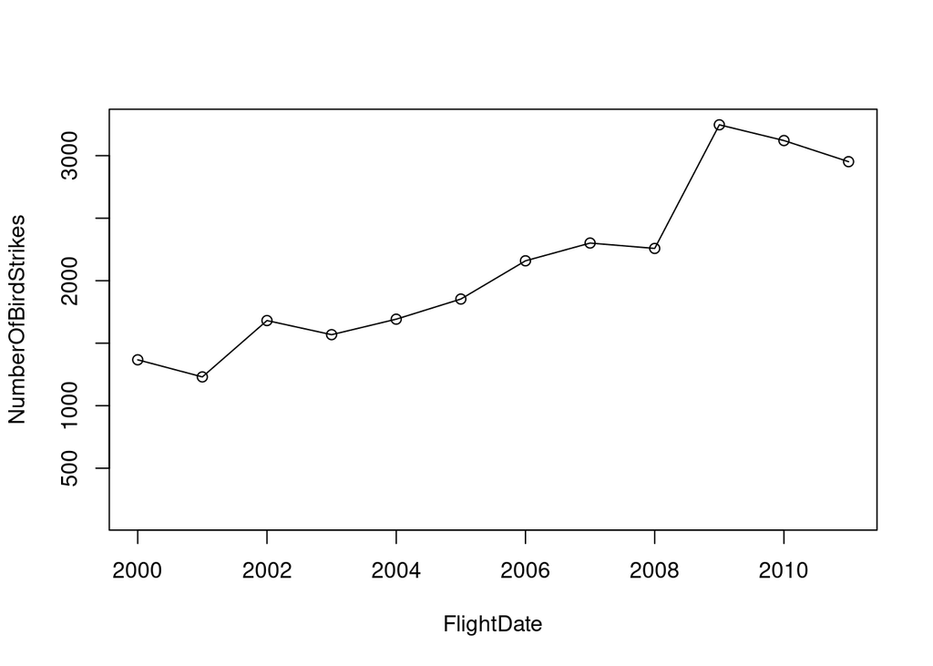

```r
plot(ans, type = "o")
```

#Create a stored procedure in MySQL (note that if you used SQLite, then you cannot complete this step) that adds a new bird strike incident to the database. You only need to include the following data: airport name, aircraft type, flight date, airline, flight phase. The remaining columns can be set with default values as defined by the table definitions. Show that the insertion worked as expected by retrieving and displaying the inserted data. Add any additional arguments to the stored procedure as needed.

```r
dbSendQuery(mydb, "DROP PROCEDURE InsertData");
```

```
## <MySQLResult:8,0,52>
```

```r
query1 = "CREATE PROCEDURE InsertData (IN AirportName nvarchar(30), IN AircraftType nvarchar(45), IN FlightDate datetime, IN Airline nvarchar(45), IN Flightphase nvarchar(45))
BEGIN
INSERT INTO practicum1.airport (`Name`) VALUES(AirportName);
INSERT INTO practicum1.aircraft (`Type`) VALUES(AircraftType);
INSERT INTO practicum1.airline_operator (`AirlineOperator`) VALUES(AirlineOperator);
INSERT INTO practicum1.bird_strike_incident (`FlightDate`, `PhaseOfFlight`) VALUES(FlightDate, Flightphase);
UPDATE bird_strike_incident SET `AirportID` = (SELECT AirportID FROM airport WHERE Name = AirportName) WHERE `FlightDate` = FlightDate AND `PhaseOfFlight` = FlightPhase;
INSERT INTO practicum1.airline_aircrafts (`AircraftTypeID`, `AirlineOperatorID`) SELECT `AircraftTypeID`, `AirlineOperatorID` FROM aircraft INNER JOIN airline_operator WHERE aircraft.Make_Model = ' ' AND aircraft.Type = AircraftType AND airline_operator.AirlineOperator = Airline;
UPDATE bird_strike_incident SET `PlaneID` = (SELECT PlaneID FROM airline_aircrafts INNER JOIN aircraft INNER JOIN airline_operator WHERE aircraft.Type = AircraftType AND airline_operator.AirlineOperator = Airline);
END"

dbSendQuery(mydb, query1);
```

```
## <MySQLResult:1,0,53>
```

```r
dbSendQuery(mydb,"call practicum1.InsertData('Delhi', 'Airplane1', '2001/10/15', 'Air India', 'Climb');")
```

```
## <MySQLResult:4,0,54>
```

```sql
SELECT * FROM aircraft WHERE `Type` = 'Airplane1';
```

1 records

| AircraftTypeID | Type | Make_Model | IsAircraftLarge |
| --- | --- | --- | --- |
| 512 | Airplane1 |  | 0 |

```sql
SELECT * FROM airport WHERE `Name` = 'Delhi';
```

1 records

| AirportID | Name | State |
| --- | --- | --- |
| 2048 | Delhi |  |

```r
dbDisconnect(mydb)
```

```
## [1] TRUE
```